# A1

Annie Liu

2023-02-11

### Data set Introduction

GSE Ascension: GSE75011

Data set title: Transcriptional profiling of TH2 cells identifies pathogenic features associated with asthma

Associated Publication: Transcriptional Profiling of Th2 Cells Identifies Pathogenic Features Associated with Asthma

### Step 1: Extracting the Dataset

Download the necessary packages needed for analysis.

```r
if (!requireNamespace("BiocManager", quietly = TRUE))
    install.packages("BiocManager")

if (!requireNamespace("GEOmetadb", quietly = TRUE))
    BiocManager::install("GEOmetadb")

if (!requireNamespace("edgeR", quietly = TRUE))
    BiocManager::install("edgeR")

if (!requireNamespace("DESeq2", quietly = TRUE))
    BiocManager::install("DESeq2")

if (!requireNamespace("biomaRt", quietly = TRUE))
    BiocManager::install("biomaRt")

if (!requireNamespace("dplyr", quietly = TRUE))
    install.packages("dplyr")


library("BiocManager")
library("GEOmetadb")
library("edgeR")
library("biomaRt")
library("DESeq2")
library("dplyr")
```

Fetch the data set and obtain information about the dataset.

```r
datadir <- "/home/rstudio/projects/GSE75011"

if(!file.exists(datadir)) {
  sfiles = getGEOSuppFiles('GSE75011')
  fnames = rownames(sfiles)
  expressionData= read.delim(fnames[1],header=TRUE,
                check.names = TRUE)
} else {
  datadir <- "/home/rstudio/projects/GSE75011/GSE75011_Raw_counts.tsv.gz"
  expressionData = read.delim(datadir)
}

# there is only one supplemental file
head(expressionData)
```

```
##             X D41_AR D04_AS D43_AR D44_AR D45_AR D46_AR D47_AR D48_AR D49_AR
## 1 1/2-SBSRNA4     10     24     18      8      8     19     16     11      4
## 2        A1BG     40     67     55     77    110     97     58     57     50
## 3    A1BG-AS1      9      6      8      1      2      4      4      2      6
## 4        A1CF      0      1      0      0      0      3      1      1      0
## 5       A2LD1     48     31     29     31     29     20     30     26     29
## 6         A2M    232     97    234     77    134     33    162     88     95
##   D50_AR D51_AR D52_AR D53_AR D54_AR D55_AR D56_AR D57_AR D58_AR D59_AR D60_AR
## 1      7     16     15     15     16     11     12     16      8     15     16
## 2     54     57     54     54     40     85     55     70     80     71     25
## 3      7      4      5      4      0      7      3      6      7      2      5
## 4      1      0      0      1      0      0      0      1      3      2      0
## 5     19     43     21     37     23     38     51      3     49     29     25
## 6    109    162    128    176    127    106    153     49    178    208     80
##   D61_AR D62_AR D63_AR D64_AR D65_AR D02_AS D01_AS D28_AS D03_AS D29_AS D30_AS
```

[output cut: 41 more lines]

```r
# checking the how many observations there are
dim(expressionData)
```

```
## [1] 19886    81
```

```r
# Information about the dataset and its platform
gse <- getGEO("GSE75011",GSEMatrix=FALSE)
knitr::kable(data.frame(head(Meta(gse))), format = "html")
```

| contact_address | contact_city | contact_country | contact_email | contact_institute | contact_name |
| --- | --- | --- | --- | --- | --- |
| 9420 Athena Cir | La Jolla | USA | vijay@lji.org | La Jolla Institute for Allergy and Immunology | Pandurangan,,Vijayanand |

```r
current_gpl <- names(GPLList(gse))[1]
current_gpl_info <- Meta(getGEO(current_gpl))
current_gpl_info$title
```

```
## [1] "Illumina HiSeq 2500 (Homo sapiens)"
```

```r
current_gpl_info$last_update_date
```

```
## [1] "Mar 27 2019"
```

```r
current_gpl_info$organism
```

```
## [1] "Homo sapiens"
```

### Step 2: Clean and Filter Dataset

The data needs to be cleaned for any duplicates and filtered for any counts that don’t make the edgeR protocol requirement. For edgeR, the protocol states that weakly expressed and noninformative features should be filtered out.

```r
#  19886    81, 19886 genes
head(expressionData)
```

```
##             X D41_AR D04_AS D43_AR D44_AR D45_AR D46_AR D47_AR D48_AR D49_AR
## 1 1/2-SBSRNA4     10     24     18      8      8     19     16     11      4
## 2        A1BG     40     67     55     77    110     97     58     57     50
## 3    A1BG-AS1      9      6      8      1      2      4      4      2      6
## 4        A1CF      0      1      0      0      0      3      1      1      0
## 5       A2LD1     48     31     29     31     29     20     30     26     29
## 6         A2M    232     97    234     77    134     33    162     88     95
##   D50_AR D51_AR D52_AR D53_AR D54_AR D55_AR D56_AR D57_AR D58_AR D59_AR D60_AR
## 1      7     16     15     15     16     11     12     16      8     15     16
## 2     54     57     54     54     40     85     55     70     80     71     25
## 3      7      4      5      4      0      7      3      6      7      2      5
## 4      1      0      0      1      0      0      0      1      3      2      0
## 5     19     43     21     37     23     38     51      3     49     29     25
## 6    109    162    128    176    127    106    153     49    178    208     80
##   D61_AR D62_AR D63_AR D64_AR D65_AR D02_AS D01_AS D28_AS D03_AS D29_AS D30_AS
```

[output cut: 41 more lines]

```r
dim(expressionData)
```

```
## [1] 19886    81
```

```r
colnames(expressionData)
```

```
##  [1] "X"      "D41_AR" "D04_AS" "D43_AR" "D44_AR" "D45_AR" "D46_AR" "D47_AR"
##  [9] "D48_AR" "D49_AR" "D50_AR" "D51_AR" "D52_AR" "D53_AR" "D54_AR" "D55_AR"
## [17] "D56_AR" "D57_AR" "D58_AR" "D59_AR" "D60_AR" "D61_AR" "D62_AR" "D63_AR"
## [25] "D64_AR" "D65_AR" "D02_AS" "D01_AS" "D28_AS" "D03_AS" "D29_AS" "D30_AS"
## [33] "D31_AS" "D32_AS" "D42_AR" "D05_AS" "D07_AS" "D08_AS" "D33_AS" "D10_AS"
## [41] "D11_AS" "D34_AS" "D12_AS" "D35_AS" "D13_AS" "D14_AS" "D36_AS" "D15_AS"
## [49] "D16_AS" "D17_AS" "D18_AS" "D27_AS" "D37_AS" "D38_AS" "D19_AS" "D39_AS"
## [57] "D20_AS" "D21_AS" "D22_AS" "D23_AS" "D24_AS" "D40_AS" "D25_AS" "D26_AS"
## [65] "D06_AS" "D09_AS" "D66_HC" "D67_HC" "D68_HC" "D69_HC" "D70_HC" "D71_HC"
## [73] "D72_HC" "D73_HC" "D74_HC" "D75_HC" "D76_HC" "D77_HC" "D78_HC" "D79_HC"
## [81] "D80_HC"
```

```r
# number of control to AR(allergy) to AS(asthma) to HC (healthy controls)
AS <- length(grep(pattern="AS$", colnames(expressionData), value=TRUE))
AR <- length(grep(pattern="AR$", colnames(expressionData), value=TRUE))
HC <- length(grep(pattern="HC$", colnames(expressionData), value=TRUE))


# Checking for duplicates
summarized_gene_counts <- sort(table(expressionData$X),
                               decreasing = TRUE)

knitr::kable(table(expressionData$X)[1:3], format="html")
```

| Var1 | Freq |
| --- | --- |
| 1/2-SBSRNA4 | 1 |
| A1BG | 1 |
| A1BG-AS1 | 1 |

```r
# there seem to not be any duplicates

cpms = cpm(expressionData[,2:81])
rownames(cpms) <- expressionData[,1]

# n needs to be the smallest group of replicates, in this case it's the HC (n = 15)
keep = rowSums(cpms > 1) >= 15
expression_data_filtered = expressionData[keep,]

# 12984    81, 12984 genes after filtering
dim(expression_data_filtered)
```

```
## [1] 12984    81
```

```r
# conditions
cond <- data.frame(lapply(colnames(expression_data_filtered)[2:81],
        FUN=function(x){unlist(strsplit(x,
                        split = "_"))[c(1,2)]}))
colnames(cond) <- colnames(expression_data_filtered)[2:81]
rownames(cond) <- c("patient_id", "condition")
cond <- data.frame(t(cond))
head(cond)
```

```
##        patient_id condition
## D41_AR        D41        AR
## D04_AS        D04        AS
## D43_AR        D43        AR
## D44_AR        D44        AR
## D45_AR        D45        AR
## D46_AR        D46        AR
```

### Step 3: Apply normalization to dataset

Create a boxplot to show the mean of the dataset.

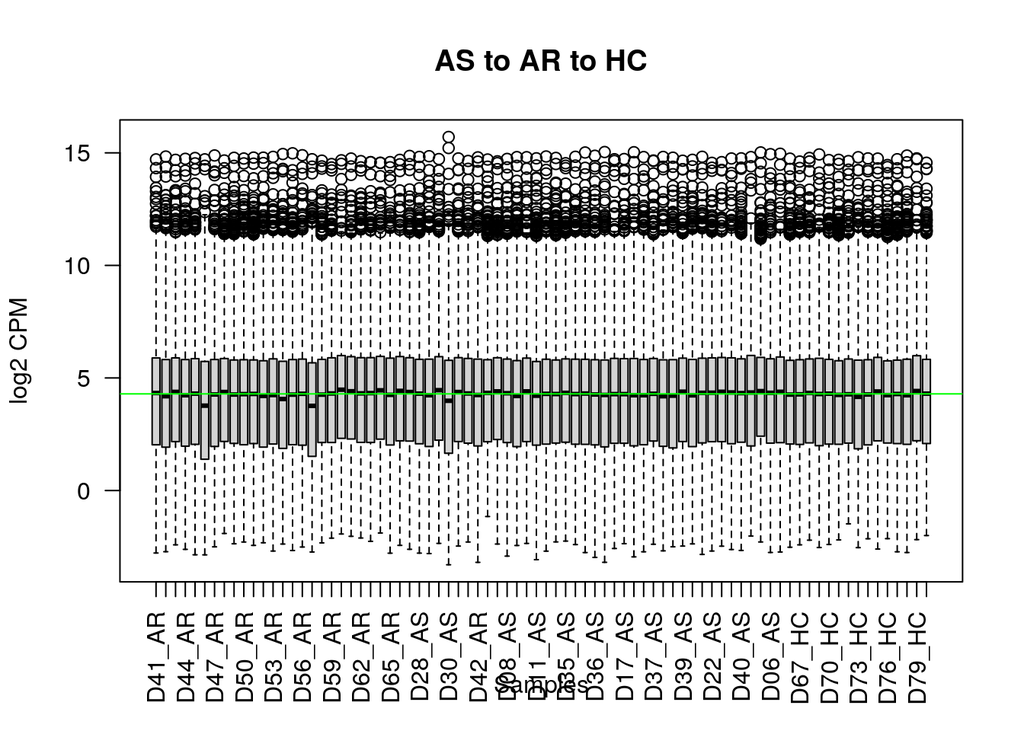

```r
## box plot of the data to see what it looks like
plotData <- log2(cpm(expression_data_filtered[,2:81]))
boxplot(plotData, xlab = "Samples", ylab = "log2 CPM",
        las = 2, cex = 1, cex.lab = 1,
        cex.axis = 1, main = "AS to AR to HC")
#draw the median on each box plot
abline(h = median(apply(plotData, 2, median)),
       col = "green", lwd = 1, lty = "solid")
```

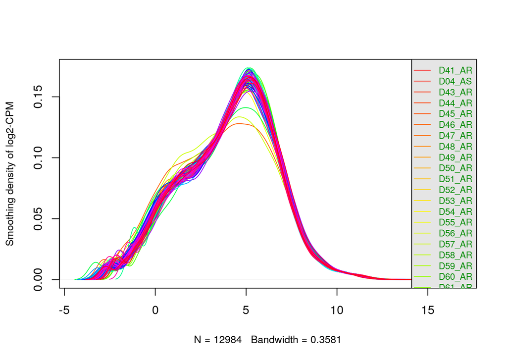

```r
counts_density <- apply(log2(cpm(expression_data_filtered[,2:81])),
                        2, density)
  #calculate the limits across all the samples

  xlim <- 0; ylim <- 0
    for (i in 1:length(counts_density)) {
      xlim <- range(c(xlim, counts_density[[i]]$x));
      ylim <- range(c(ylim, counts_density[[i]]$y))
    }
    cols <- rainbow(length(counts_density))
    ltys <- rep(1, length(counts_density))
    #plot the first density plot to initialize the plot
    plot(counts_density[[1]], xlim=xlim, ylim=ylim, type="n",
         ylab="Smoothing density of log2-CPM",
         main="", cex.lab = 0.85)
    #plot each line
    for (i in 1:length(counts_density))
      lines(counts_density[[i]], col=cols[i], lty=ltys[i])
    #create legend
    legend("topright", colnames(plotData),
           col=cols, lty=ltys, cex=0.75,
           border ="blue",  text.col = "green4",
           merge = TRUE, bg = "gray90")
```

There definitely seems to centering around a particular mean in this dataset; however, there is a definitive S shaped bump on the left side of the graph. Thus, normalization is most certainly necessary.

While the owners of the dataset originally used DESeq2 to analyze their differentially expressed data, I would like to try using the edgeR protocol as these two methods are based on similar hypotheses.

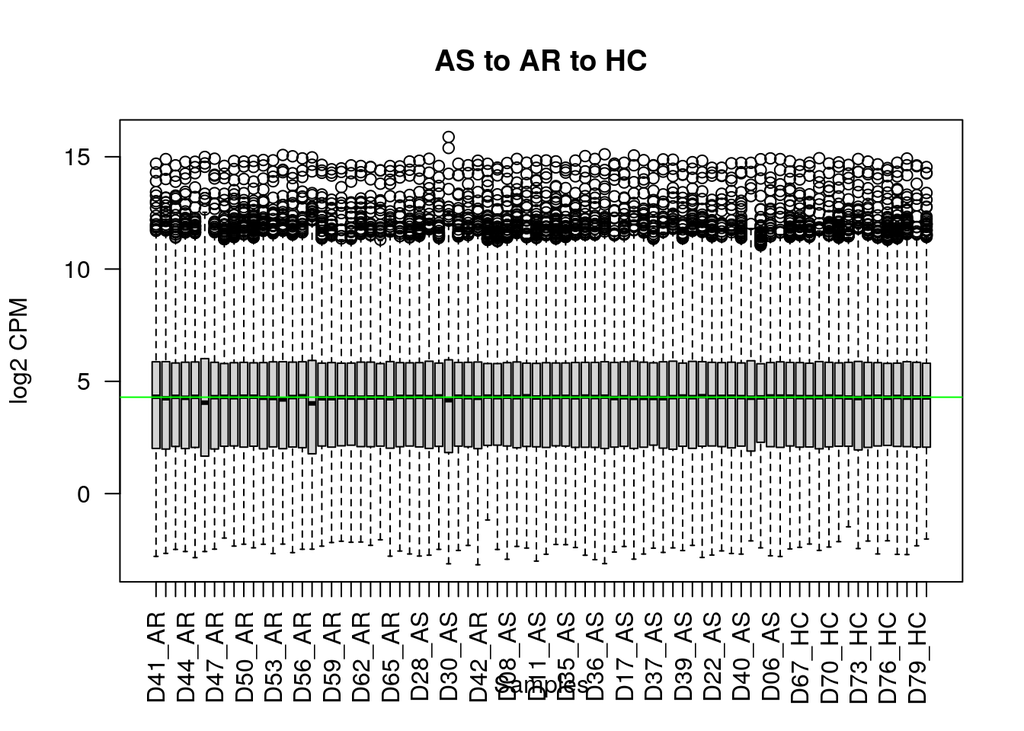

```r
# edgeR normalization
filtered_data_matrix <- as.matrix(expression_data_filtered[,2:81])
rownames(filtered_data_matrix) <- expression_data_filtered$X
d = DGEList(counts=filtered_data_matrix, group=cond$condition)

d = calcNormFactors(d)

normalized_cpm <- cpm(d)

# normalized box plot
plotData_n <- log2(normalized_cpm)

normalized_boxplot <- boxplot(plotData_n, xlab = "Samples", ylab = "log2 CPM",
        las = 2, cex = 1, cex.lab = 1,
        cex.axis = 1, main = "AS to AR to HC")
#draw the median on each box plot
abline(h = median(apply(plotData_n, 2, median)),
       col = "green", lwd = 1, lty = "solid")
```

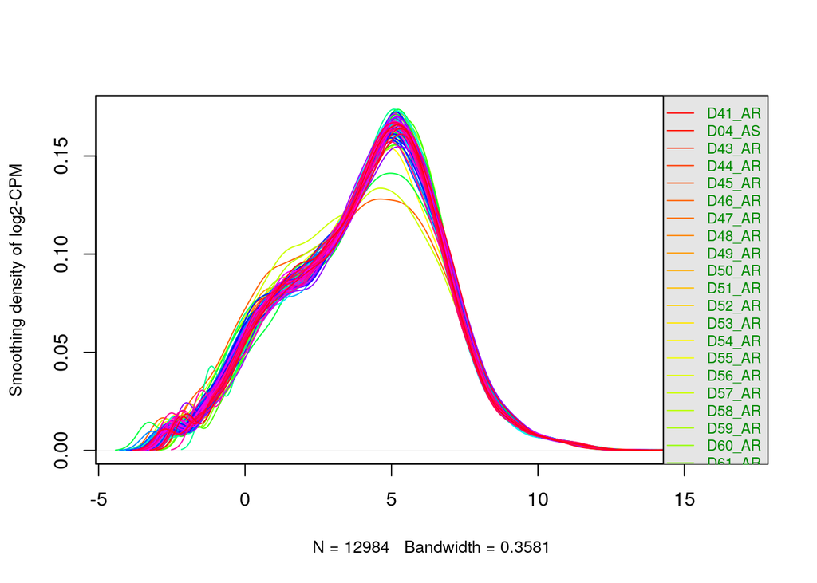

```r
counts_density_n <- apply(log2(normalized_cpm),
                        2, density)
  #calculate the limits across all the samples
    xlim <- 0; ylim <- 0
    for (i in 1:length(counts_density_n)) {
      xlim <- range(c(xlim, counts_density_n[[i]]$x));
      ylim <- range(c(ylim, counts_density_n[[i]]$y))
    }
    cols <- rainbow(length(counts_density_n))
    ltys <- rep(1, length(counts_density_n))
    #plot the first density plot to initialize the plot
    plot(counts_density_n[[1]], xlim=xlim, ylim=ylim, type="n",
         ylab="Smoothing density of log2-CPM",
         main="", cex.lab = 0.85)
    #plot each line
    for (i in 1:length(counts_density_n))
      lines(counts_density[[i]], col=cols[i], lty=ltys[i])
    #create legend
    legend("topright", colnames(plotData_n),
           col=cols, lty=ltys, cex=0.75,
           border ="blue",  text.col = "green4",
           merge = TRUE, bg = "gray90")
```

### Step 4: Exploratory Data Analysis

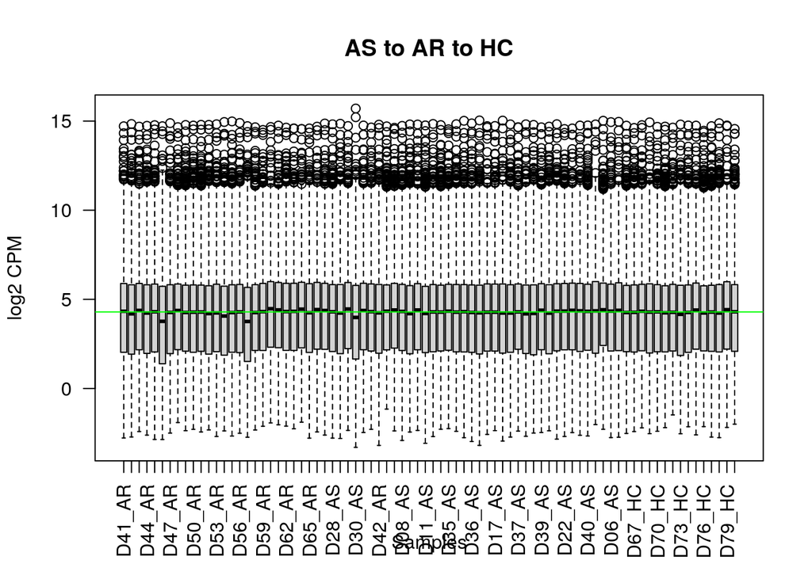

```r
# nonnormalized boxplot
plotData <- log2(cpm(expression_data_filtered[,2:81]))
boxplot(plotData, xlab = "Samples", ylab = "log2 CPM",
        las = 2, cex = 1, cex.lab = 1,
        cex.axis = 1, main = "AS to AR to HC")
#draw the median on each box plot
abline(h = median(apply(plotData, 2, median)),
       col = "green", lwd = 1, lty = "solid")
```

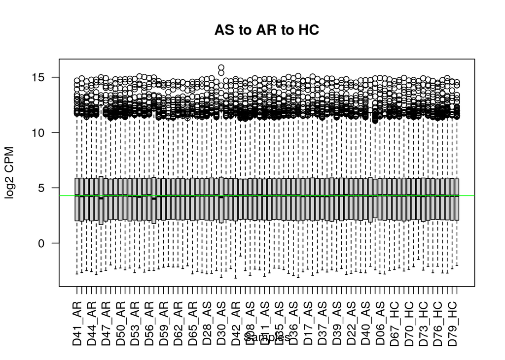

```r
# normalized box plot
plotData_n <- log2(normalized_cpm)

boxplot(plotData_n, xlab = "Samples", ylab = "log2 CPM",
        las = 2, cex = 1, cex.lab = 1,
        cex.axis = 1, main = "AS to AR to HC")
#draw the median on each box plot
abline(h = median(apply(plotData_n, 2, median)),
       col = "green", lwd = 1, lty = "solid")
```

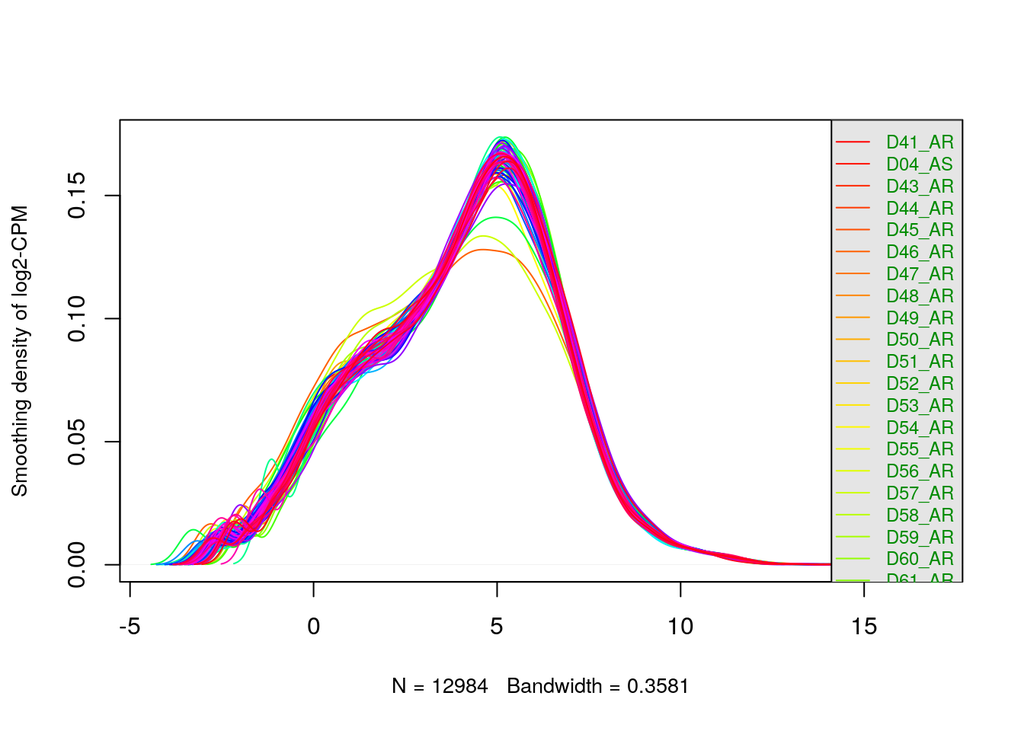

```r
# nonnormalized density plot
counts_density <- apply(log2(cpm(expression_data_filtered[,2:81])),
                        2, density)
  #calculate the limits across all the samples

  xlim <- 0; ylim <- 0
    for (i in 1:length(counts_density)) {
      xlim <- range(c(xlim, counts_density[[i]]$x));
      ylim <- range(c(ylim, counts_density[[i]]$y))
    }
    cols <- rainbow(length(counts_density))
    ltys <- rep(1, length(counts_density))
    #plot the first density plot to initialize the plot
    plot(counts_density[[1]], xlim=xlim, ylim=ylim, type="n",
         ylab="Smoothing density of log2-CPM",
         main="", cex.lab = 0.85)
    #plot each line
    for (i in 1:length(counts_density))
      lines(counts_density[[i]], col=cols[i], lty=ltys[i])
    #create legend
    legend("topright", colnames(plotData),
           col=cols, lty=ltys, cex=0.75,
           border ="blue",  text.col = "green4",
           merge = TRUE, bg = "gray90")
```

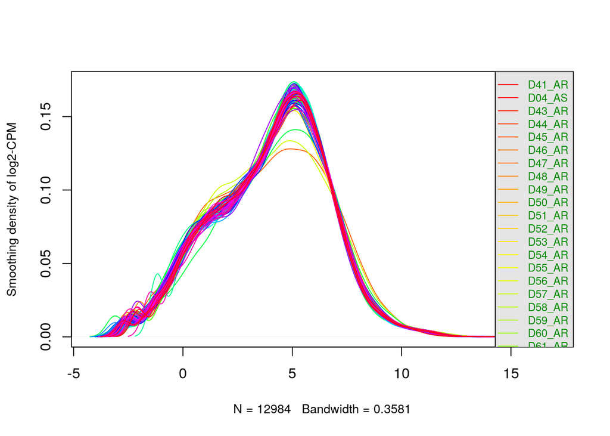

```r
# normalized density plot
counts_density_n <- apply(log2(normalized_cpm),
                        2, density)
  #calculate the limits across all the samples
    xlim <- 0; ylim <- 0
    for (i in 1:length(counts_density_n)) {
      xlim <- range(c(xlim, counts_density_n[[i]]$x));
      ylim <- range(c(ylim, counts_density_n[[i]]$y))
    }
    cols <- rainbow(length(counts_density_n))
    ltys <- rep(1, length(counts_density_n))
    #plot the first density plot to initialize the plot
    plot(counts_density_n[[1]], xlim=xlim, ylim=ylim, type="n",
         ylab="Smoothing density of log2-CPM",
         main="", cex.lab = 0.85)
    #plot each line
    for (i in 1:length(counts_density_n))
      lines(counts_density_n[[i]], col=cols[i], lty=ltys[i])
    #create legend
    legend("topright", colnames(plotData_n),
           col=cols, lty=ltys, cex=0.75,
           border ="blue",  text.col = "green4",
           merge = TRUE, bg = "gray90")
```

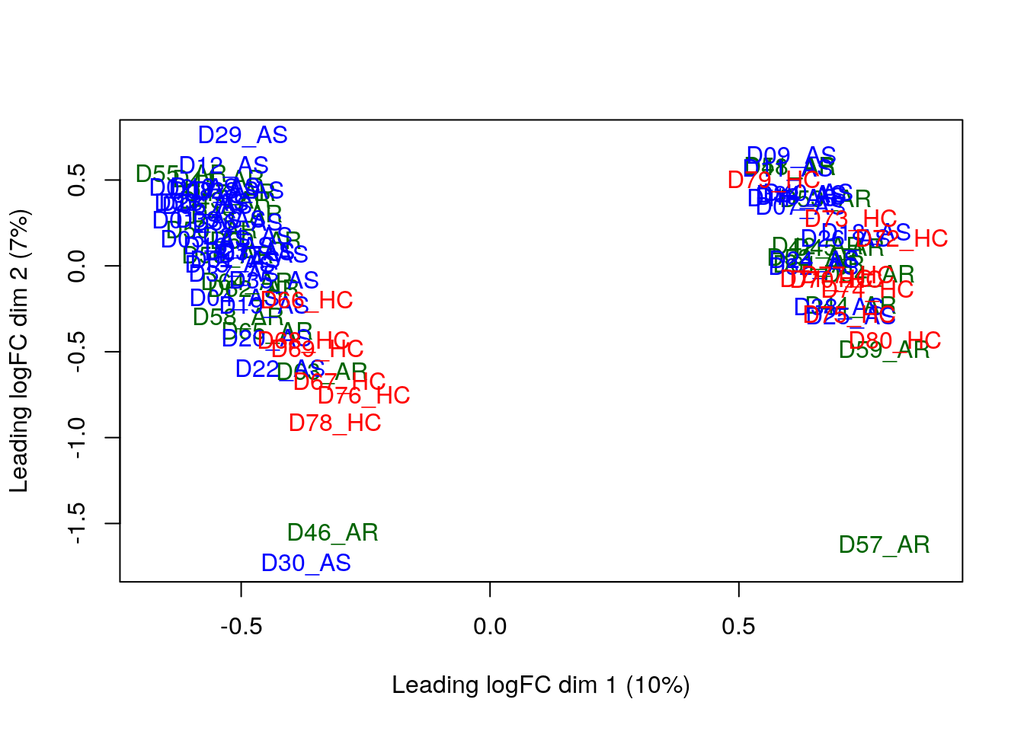

```r
# MDS plot, a multidimensional scaling plot
plotMDS(d, labels=rownames(cond), col = c("darkgreen", "blue", "red")[factor(cond$condition)])
```

There seems to be two very clear clusters with much of the AS group clustering together. Curiously, it seems like the HC (healthy control group) is split between the two clusters.

Let’s calculate dispersion.

```r
model_design <- model.matrix(~cond$condition+0)
disp <- estimateDisp(d, model_design)
head(disp)
```

[output not shown]

[output cut: 52 more lines]

```
##
## $AveLogCPM
## [1] 1.5074185 3.4719766 0.2691796 2.7544180 4.3969576 0.5379589
##
## $trend.method
## [1] "locfit"
##
## $prior.df
## [1] 8.259859
##
## $prior.n
## [1] 0.1072709
##
## $span
## [1] 0.2965417
```

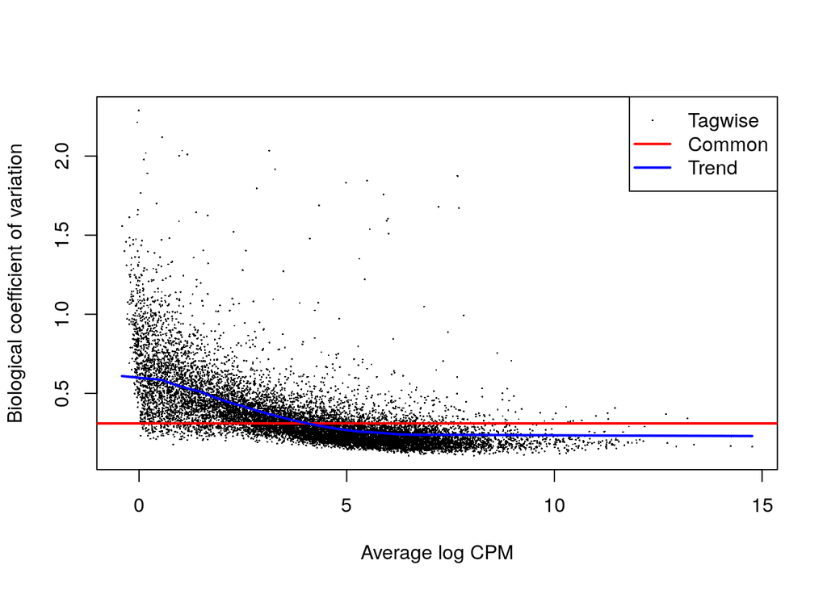

```r
#plot BCV graph
plotBCV(disp, col.tagwise = "black",col.common = "red")
```

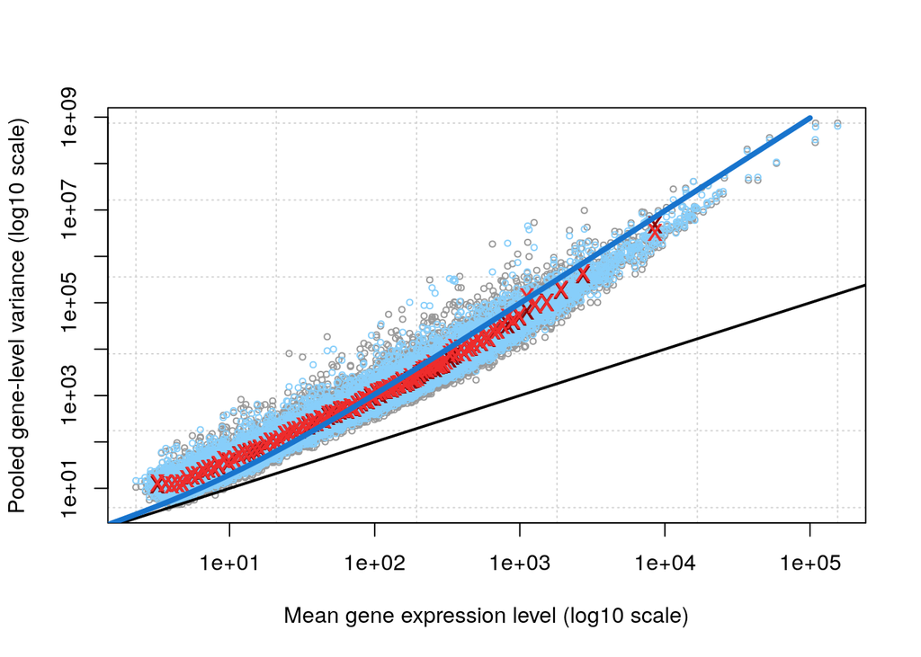

```r
#plot mean-variance graph
plotMeanVar(disp, show.raw.vars = TRUE, show.tagwise.vars = TRUE, NBline = TRUE,
                   show.ave.raw.vars = TRUE,
                   show.binned.common.disp.vars = TRUE)
```

### Step 5: Map Identifiers

In this final step, we want to map the gene names to Ensembl as this dataset only came with the gene name that might be HGNC, but I don’t have true confirmation from the authors that it is HGNC. I found this package on CRAN called HGNChelper to see if it is the gene name table is HGNC. There is a function HGNChelper::checkGeneSymbols that identifies symbols that might be outdated and returns a suggested HGNC version of the gene name https://cran.r-project.org/web/packages/HGNChelper/vignettes/index.html

```r
# For clarity, I'm renaming the X column as gene
names(expression_data_filtered)[names(expression_data_filtered) == "X"] <- "gene"
head(expression_data_filtered)
```

```
##          gene D41_AR D04_AS D43_AR D44_AR D45_AR D46_AR D47_AR D48_AR D49_AR
## 1 1/2-SBSRNA4     10     24     18      8      8     19     16     11      4
## 2        A1BG     40     67     55     77    110     97     58     57     50
## 3    A1BG-AS1      9      6      8      1      2      4      4      2      6
## 5       A2LD1     48     31     29     31     29     20     30     26     29
## 6         A2M    232     97    234     77    134     33    162     88     95
## 7       A2ML1      3      7      8      1      7      5      4      6      3
##   D50_AR D51_AR D52_AR D53_AR D54_AR D55_AR D56_AR D57_AR D58_AR D59_AR D60_AR
## 1      7     16     15     15     16     11     12     16      8     15     16
## 2     54     57     54     54     40     85     55     70     80     71     25
## 3      7      4      5      4      0      7      3      6      7      2      5
## 5     19     43     21     37     23     38     51      3     49     29     25
## 6    109    162    128    176    127    106    153     49    178    208     80
## 7      3      4      2      5      5      7      8     11     10     10      8
##   D61_AR D62_AR D63_AR D64_AR D65_AR D02_AS D01_AS D28_AS D03_AS D29_AS D30_AS
```

[output cut: 41 more lines]

```r
if (!requireNamespace("HGNChelper", quietly = TRUE))
    BiocManager::install("HGNChelper")

library("HGNChelper")

# Take all the gene names and check if there is any NA in the list
gene_vec <- expression_data_filtered[,1]
any(is.na(gene_vec)) # FALSE
```

```
## [1] FALSE
```

```r
#This function takes a vector and checks if the gene symbols match up to HGNC standards
check_gene_vec_hgnc <- checkGeneSymbols(gene_vec, unmapped.as.na = FALSE, map = NULL, species = "human")

#check the number of genes where the gene name is not HGNC approved
length(which(check_gene_vec_hgnc$Approved == "FALSE")) # 1658
```

```
## [1] 1658
```

```r
length(gene_vec) # 12984 genes in total
```

```
## [1] 12984
```

```r
(1658/12984)*100 # just under 13% of the gene names are not to HGNC standard
```

```
## [1] 12.76956
```

```r
# check if any of the gene to HGNC conversions are NA, ie, where there was no mapping
any(is.na(check_gene_vec_hgnc$Suggested.Symbol)) # FALSE
```

```
## [1] FALSE
```

```r
gene_vec_hgnc <- check_gene_vec_hgnc$Suggested.Symbol

# check of the length of these vectors are the same
length(gene_vec) == length(gene_vec_hgnc) # TRUE
```

```
## [1] TRUE
```

```r
expression_data_filtered <- cbind(gene_vec_hgnc, expression_data_filtered)

names(expression_data_filtered)[names(expression_data_filtered) == "gene_vec_hgnc"] <- "gene_hgnc"
head(expression_data_filtered)
```

```
##    gene_hgnc        gene D41_AR D04_AS D43_AR D44_AR D45_AR D46_AR D47_AR
## 1 SEC24B-AS1 1/2-SBSRNA4     10     24     18      8      8     19     16
## 2       A1BG        A1BG     40     67     55     77    110     97     58
## 3   A1BG-AS1    A1BG-AS1      9      6      8      1      2      4      4
## 5      GGACT       A2LD1     48     31     29     31     29     20     30
## 6        A2M         A2M    232     97    234     77    134     33    162
## 7      A2ML1       A2ML1      3      7      8      1      7      5      4
##   D48_AR D49_AR D50_AR D51_AR D52_AR D53_AR D54_AR D55_AR D56_AR D57_AR D58_AR
## 1     11      4      7     16     15     15     16     11     12     16      8
## 2     57     50     54     57     54     54     40     85     55     70     80
## 3      2      6      7      4      5      4      0      7      3      6      7
## 5     26     29     19     43     21     37     23     38     51      3     49
## 6     88     95    109    162    128    176    127    106    153     49    178
## 7      6      3      3      4      2      5      5      7      8     11     10
##   D59_AR D60_AR D61_AR D62_AR D63_AR D64_AR D65_AR D02_AS D01_AS D28_AS D03_AS
```

[output cut: 41 more lines]

```r
# we're trying to get HGNC to ensembl
# code adapted from https://www.biostars.org/p/430015/
if (!requireNamespace("org.Hs.eg.db", quietly = TRUE)) {
    BiocManager::install("org.Hs.eg.db")
}

if (!requireNamespace("AnnotationDbi", quietly = TRUE)) {
    BiocManager::install("AnnotationDbi")
}

library("AnnotationDbi")
library("org.Hs.eg.db")
expression_data_filtered$enID = mapIds(org.Hs.eg.db,
                    keys=expression_data_filtered$gene_hgnc,
                    column="ENSEMBL",
                    keytype="SYMBOL",
                    multiVals="first")
head(expression_data_filtered)
```

```
##    gene_hgnc        gene D41_AR D04_AS D43_AR D44_AR D45_AR D46_AR D47_AR
## 1 SEC24B-AS1 1/2-SBSRNA4     10     24     18      8      8     19     16
## 2       A1BG        A1BG     40     67     55     77    110     97     58
## 3   A1BG-AS1    A1BG-AS1      9      6      8      1      2      4      4
## 5      GGACT       A2LD1     48     31     29     31     29     20     30
## 6        A2M         A2M    232     97    234     77    134     33    162
## 7      A2ML1       A2ML1      3      7      8      1      7      5      4
##   D48_AR D49_AR D50_AR D51_AR D52_AR D53_AR D54_AR D55_AR D56_AR D57_AR D58_AR
## 1     11      4      7     16     15     15     16     11     12     16      8
## 2     57     50     54     57     54     54     40     85     55     70     80
## 3      2      6      7      4      5      4      0      7      3      6      7
## 5     26     29     19     43     21     37     23     38     51      3     49
## 6     88     95    109    162    128    176    127    106    153     49    178
## 7      6      3      3      4      2      5      5      7      8     11     10
##   D59_AR D60_AR D61_AR D62_AR D63_AR D64_AR D65_AR D02_AS D01_AS D28_AS D03_AS
```

[output cut: 41 more lines]

```r
#moving the enID column to the front for formatting
expression_data_filtered <- expression_data_filtered %>%
  dplyr::select(enID, everything())
head(expression_data_filtered)
```

```
##              enID  gene_hgnc        gene D41_AR D04_AS D43_AR D44_AR D45_AR
## 1 ENSG00000247950 SEC24B-AS1 1/2-SBSRNA4     10     24     18      8      8
## 2 ENSG00000121410       A1BG        A1BG     40     67     55     77    110
## 3 ENSG00000268895   A1BG-AS1    A1BG-AS1      9      6      8      1      2
## 5 ENSG00000134864      GGACT       A2LD1     48     31     29     31     29
## 6 ENSG00000175899        A2M         A2M    232     97    234     77    134
## 7 ENSG00000166535      A2ML1       A2ML1      3      7      8      1      7
##   D46_AR D47_AR D48_AR D49_AR D50_AR D51_AR D52_AR D53_AR D54_AR D55_AR D56_AR
## 1     19     16     11      4      7     16     15     15     16     11     12
## 2     97     58     57     50     54     57     54     54     40     85     55
## 3      4      4      2      6      7      4      5      4      0      7      3
## 5     20     30     26     29     19     43     21     37     23     38     51
## 6     33    162     88     95    109    162    128    176    127    106    153
## 7      5      4      6      3      3      4      2      5      5      7      8
##   D57_AR D58_AR D59_AR D60_AR D61_AR D62_AR D63_AR D64_AR D65_AR D02_AS D01_AS
```

[output cut: 41 more lines]

```r
normal_counts_df <- as.data.frame(normalized_cpm)
normal_counts_df_annotated <- cbind(expression_data_filtered[, 1:3], normal_counts_df)

# check if any of the gene names are duplicated after the HUGO symbol conversion
any(duplicated(normal_counts_df_annotated$gene_hgnc)) # TRUE
```

```
## [1] TRUE
```

```r
# Final annotated counts notebook
normal_counts_df_annotated <- normal_counts_df_annotated[!duplicated(normal_counts_df_annotated$gene_hgnc),] # remove those duplicates

# check if there are missing mappings
any(is.na(normal_counts_df_annotated$enID)) # TRUE
```

```
## [1] TRUE
```

```r
length(which(is.na(normal_counts_df_annotated$enID))) # 810
```

```
## [1] 810
```

```r
length(normal_counts_df_annotated$gene_hgnc) # 12973
```

```
## [1] 12973
```

```r
hgnc_en_diff <- length(normal_counts_df_annotated$gene_hgnc) - length(which(is.na(expression_data_filtered$enID)))
hgnc_en_diff #12161
```

```
## [1] 12161
```

```r
hgnc_en_diff_proportion <- (length(which(is.na(expression_data_filtered$enID))) /length(expression_data_filtered$gene_hgnc)) *100
hgnc_en_diff_proportion # 6.253851 of the genes without an ensembl id
```

```
## [1] 6.253851
```

The final table is normal_counts_df_annotated, and it has HUGO and Ensembl IDs as columns. Following the final example on the lecture 5 slides, I opted to keep the HGNC symbols as a column rather than naming the rows of the table with the HGNC symbols.

```r
head(normal_counts_df_annotated)
```

```
##              enID  gene_hgnc        gene     D41_AR     D04_AS    D43_AR
## 1 ENSG00000247950 SEC24B-AS1 1/2-SBSRNA4  1.4419013  3.8004830  3.217112
## 2 ENSG00000121410       A1BG        A1BG  5.7676053 10.6096817  9.830066
## 3 ENSG00000268895   A1BG-AS1    A1BG-AS1  1.2977112  0.9501207  1.429828
## 5 ENSG00000134864      GGACT       A2LD1  6.9211263  4.9089572  5.183126
## 6 ENSG00000175899        A2M         A2M 33.4521105 15.3602854 41.822462
## 7 ENSG00000166535      A2ML1       A2ML1  0.4325704  1.1084742  1.429828
##       D44_AR     D45_AR     D46_AR     D47_AR     D48_AR     D49_AR     D50_AR
## 1  1.3401212  1.1103945  3.1803451  2.8819582  2.7948940  0.7926092  1.4705275
## 2 12.8986665 15.2679239 16.2364985 10.4470984 14.4826328  9.9076151 11.3440691
## 3  0.1675151  0.2775986  0.6695463  0.7204895  0.5081626  1.1889138  1.4705275
## 5  5.1929696  4.0251799  3.3477316  5.4036716  6.6061132  5.7464167  3.9914317
## 6 12.8986665 18.5991072  5.5237572 29.1798265 22.3591524 18.8244686 22.8982136
## 7  0.1675151  0.9715952  0.8369329  0.7204895  1.5244877  0.5944569  0.6302261
##       D51_AR    D52_AR     D53_AR    D54_AR    D55_AR     D56_AR     D57_AR
```

[output cut: 69 more lines]

### Step 6: Document

**What are the control and test conditions of the dataset?** The control is the healthy cohort that does not have allergic rhinitis nor asthma. The test conditions are the cohort with allergic rhinitis and the cohort with asthma.

**Why is the dataset of interest to you?** This dataset is of interest to me as I am someone with a dust and cat allergy, and I am also asthmatic. I’ve always wondered why I have developed this sort of pathology that has prevented me from enjoying cats and running without an inhaler. Thus, this dataset explores this question in particular.

**Were there expression values that were not unique for specific genes? How did you handle these?** After HUGO symbol conversion, I removed any duplicate genes from the dataset.

**Were there expression values that could not be mapped to current HUGO symbols?** I had a specific instance where I was provided with gene symbols that all could be converted to HGNC symbols, but I did not have the Ensembl IDs for the genes. About 6% of the genes could not be mapped to Ensembl IDs. I will leave those in for now and use HUGO symbols as needed, but I may investigate other methods for mapping to Ensembl IDs.

**How many outliers were removed?** No signficant outliers were identified, and thus, none were removed.

**How did you handle replicates?** This dataset contained 25 AR replicates, 40 AS replicates, and 15 HC replicates. I followed the edgeR protocol and applied normalization based off of the lowest number of replicates, that being 15. Normalization was then applied to remove technical variation.

### References

Conversion of gene name to ensembl ID. (n.d.). Biostars.org. Retrieved February 20, 2023, from https://www.biostars.org/p/430015/

Isserlin, R. (2023). Lecture 4 - Data Exploration and Normalization. Quercus. https://q.utoronto.ca/courses/294979/files/24035536?module_item_id=4287827

Isserlin, R. (2023). Lecture 5 - Data Exploration and Identifier Mapping. Quercus. https://q.utoronto.ca/courses/294979/files/24035540?module_item_id=4287835

Seumois, G., Zapardiel-Gonzalo, J., White, B., Singh, D., Schulten, V., Dillon, M., Hinz, D., Broide, D. H., Sette, A., Peters, B., & Vijayanand, P. (2016). Transcriptional Profiling of Th2 Cells Identifies Pathogenic Features Associated with Asthma. Journal of immunology (Baltimore, Md. : 1950), 197(2), 655–664. https://doi.org/10.4049/jimmunol.1600397